# Topic 2-03: Use clusterProfiler for ORA

Zuguang Gu z.gu@dkfz.de

2025-03-02

Let’s start with a vector of DE genes:

```r
lt = readRDS(system.file("extdata", "ora.rds", package = "GSEAtraining"))
diff_gene = lt$diff_gene
bg_gene = lt$bg_gene
head(diff_gene)
```

```
## [1] "FGR"    "NIPAL3" "LAP3"   "CASP10" "CAMKK1" "PRSS22"
```

Load the **clusterProfiler** package.

```r
library(clusterProfiler)
```

**clusterProfiler** supports several major gene ID types in the input, but it is suggested to use Entrez IDs as the input because it is the “central gene ID type” in many databases/datasets.

We convert `diff_gene` to Entrez IDs. Note some genes may be lost due to the conversion.

```r
library(GSEAtraining)
diff_gene = convert_to_entrez_id(diff_gene)
```

```
##   gene id might be SYMBOL (p =  0.990 )
```

```r
head(diff_gene)
```

```
##     FGR  NIPAL3    LAP3  CASP10  CAMKK1  PRSS22
##  "2268" "57185" "51056"   "843" "84254" "64063"
```

```r
length(diff_gene)
```

```
## [1] 835
```

Next we perform ORA on different gene set sources.

## GO enrichment

```r
library(org.Hs.eg.db)
tb = enrichGO(gene = diff_gene, ont = "BP", OrgDb = org.Hs.eg.db)
head(tb)
```

```
##                    ID                                  Description GeneRatio
## GO:0002274 GO:0002274                 myeloid leukocyte activation    51/779
## GO:0002237 GO:0002237     response to molecule of bacterial origin    63/779
## GO:0032496 GO:0032496               response to lipopolysaccharide    61/779
## GO:0050729 GO:0050729 positive regulation of inflammatory response    40/779
## GO:0050727 GO:0050727          regulation of inflammatory response    66/779
## GO:0002697 GO:0002697        regulation of immune effector process    63/779
##              BgRatio RichFactor FoldEnrichment   zScore       pvalue
## GO:0002274 247/18986  0.2064777       5.032331 13.19430 5.149704e-22
## GO:0002237 375/18986  0.1680000       4.094542 12.51936 6.945328e-22
## GO:0032496 354/18986  0.1723164       4.199742 12.57018 8.355530e-22
## GO:0050729 162/18986  0.2469136       6.017845 13.26703 1.676133e-20
## GO:0050727 438/18986  0.1506849       3.672534 11.70487 3.037134e-20
## GO:0002697 410/18986  0.1536585       3.745008 11.62289 8.217123e-20
##                p.adjust       qvalue
## GO:0002274 1.409021e-18 1.099119e-18
## GO:0002237 1.409021e-18 1.099119e-18
## GO:0032496 1.409021e-18 1.099119e-18
## GO:0050729 2.119890e-17 1.653638e-17
## GO:0050727 3.072972e-17 2.397098e-17
## GO:0002697 6.928404e-17 5.404561e-17
##                                                                                                                                                                                                                                                                                                          …
## GO:0002274                                                                                       2268/7305/6556/22904/8692/3430/54209/50487/3696/3458/7474/91…
## GO:0002237                                   4843/6401/6556/50943/22904/5743/2920/3595/54209/3055/54/7302…
## GO:0032496                                            4843/6401/6556/50943/22904/5743/2920/3595/54209/3055/54/7302…
## GO:0050729                                                                                                                                               8692/3430/5743/58484/54209/5008/50487/4210/5054/59341/3458/7…
## GO:0050727 2268/6401/3082/50943/22904/8692/3430/55737/5743/58484/54209/…
## GO:0002697                       2268/4843/7305/50943/7037/2219/3383/54209/50487/54/3458/942/…
##            Count
## GO:0002274    51
## GO:0002237    63
## GO:0032496    61
## GO:0050729    40
## GO:0050727    66
## GO:0002697    63
```

## KEGG enrichment

```r
tb = enrichKEGG(gene = diff_gene, organism = "hsa")
head(tb)
```

```
##                                      category
## hsa04060 Environmental Information Processing
## hsa04061 Environmental Information Processing
## hsa04657                   Organismal Systems
## hsa04380                   Organismal Systems
## hsa04668 Environmental Information Processing
## hsa05323                       Human Diseases
##                                  subcategory       ID
## hsa04060 Signaling molecules and interaction hsa04060
## hsa04061 Signaling molecules and interaction hsa04061
## hsa04657                       Immune system hsa04657
## hsa04380        Development and regeneration hsa04380
## hsa04668                 Signal transduction hsa04668
## hsa05323                      Immune disease hsa05323
##                                                            Description
## hsa04060                        Cytokine-cytokine receptor interaction
## hsa04061 Viral protein interaction with cytokine and cytokine receptor
## hsa04657                                       IL-17 signaling pathway
## hsa04380                                    Osteoclast differentiation
## hsa04668                                         TNF signaling pathway
## hsa05323                                          Rheumatoid arthritis
##          GeneRatio  BgRatio RichFactor FoldEnrichment   zScore       pvalue
## hsa04060    50/452 298/8535  0.1677852       3.168246 9.009305 1.539612e-13
## hsa04061    27/452 100/8535  0.2700000       5.098341 9.748207 8.613618e-13
## hsa04657    25/452  95/8535  0.2631579       4.969143 9.199126 1.148639e-11
## hsa04380    29/452 143/8535  0.2027972       3.829368 8.068334 2.535667e-10
## hsa04668    26/452 119/8535  0.2184874       4.125641 8.119308 3.971319e-10
## hsa05323    23/452  95/8535  0.2421053       4.571612 8.277783 4.807896e-10
##              p.adjust       qvalue
## hsa04060 4.926759e-11 4.294708e-11
## hsa04061 1.378179e-10 1.201373e-10
## hsa04657 1.225215e-09 1.068033e-09
## hsa04380 2.028533e-08 1.768294e-08
## hsa04668 2.541644e-08 2.215578e-08
## hsa05323 2.564211e-08 2.235250e-08
##                                                                                                                                                                                                                                                                   geneID
## hsa04060 53832/608/2920/3595/3589/5008/1440/6354/6347/55801/3458/3552…
## hsa04061                                                                                                                     53832/2920/6354/6347/8809/8807/729230/6372/51554/3569/4283/56477/3577/2921/6374/5196/2919/3627/6373/3576/8794/1237/3579/6351/9560/6349/6348
## hsa04657                                                                                                                                  5743/2920/1440/6354/6347/3458/727897/6372/3553/2354/3569/4322/6279/3934/4314/6280/2921/6374/2919/3627/3576/2353/1051/8061/4312
## hsa04380                                                                                                       7305/54209/10326/54/11024/3458/3552/6772/2274/4688/8503/3553/2354/10288/7006/2212/2209/2215/6850/2353/126014/3726/8061/9021/353514/2214/11025/11027/79168
## hsa04668                                                                                                                            843/64285/6401/5743/2920/3383/6347/8809/8503/6372/3659/3553/3569/4314/4323/8986/2921/6374/2919/64127/197259/3627/2353/3726/1051/9021
## hsa05323                                                                                                                                                2920/3383/3589/54/6347/10312/3458/942/3552/6372/3553/3569/7097/4314/8741/2921/6374/2919/3576/2353/4312/6349/6348
##          Count
## hsa04060    50
## hsa04061    27
## hsa04657    25
## hsa04380    29
## hsa04668    26
## hsa05323    23
```

## Reactome enrichment

```r
library(ReactomePA)
tb = enrichPathway(gene = diff_gene, organism = "human")
head(tb)
```

```
##                          ID
## R-HSA-6798695 R-HSA-6798695
## R-HSA-6783783 R-HSA-6783783
## R-HSA-380108   R-HSA-380108
## R-HSA-449147   R-HSA-449147
## R-HSA-198933   R-HSA-198933
## R-HSA-6785807 R-HSA-6785807
##                                                                            Description
## R-HSA-6798695                                                 Neutrophil degranulation
## R-HSA-6783783                                                 Interleukin-10 signaling
## R-HSA-380108                                       Chemokine receptors bind chemokines
## R-HSA-449147                                                 Signaling by Interleukins
## R-HSA-198933  Immunoregulatory interactions between a Lymphoid and a non-Lymphoid cell
## R-HSA-6785807                               Interleukin-4 and Interleukin-13 signaling
##               GeneRatio   BgRatio RichFactor FoldEnrichment    zScore
## R-HSA-6798695    71/599 479/11146  0.1482255       2.758132  9.373182
## R-HSA-6783783    21/599  47/11146  0.4468085       8.314070 11.974436
## R-HSA-380108     22/599  59/11146  0.3728814       6.938457 10.898872
## R-HSA-449147     64/599 473/11146  0.1353066       2.517741  8.038480
## R-HSA-198933     27/599 133/11146  0.2030075       3.777499  7.679198
## R-HSA-6785807    23/599 108/11146  0.2129630       3.962747  7.373101
##                     pvalue     p.adjust       qvalue
## R-HSA-6798695 2.519471e-15 2.935183e-12 2.797938e-12
## R-HSA-6783783 5.190031e-15 3.023193e-12 2.881833e-12
## R-HSA-380108  1.099867e-13 4.271149e-11 4.071437e-11
## R-HSA-449147  4.612427e-12 1.343369e-09 1.280555e-09
## R-HSA-198933  1.607939e-09 3.746498e-07 3.571317e-07
## R-HSA-6785807 1.007665e-08 1.956549e-06 1.865064e-06
##                                                                                                                                                                                                                                                                                                          …
## R-HSA-6798695 2268/64386/5329/7305/55/6556/2219/4680/4069/5836/10326/10562…
## R-HSA-6783783                                                                                                                                                                                                                                                                                   5743/2920…
## R-HSA-380108                                                                                                                                                                                                                                                                           2920/6354/6347/729…
## R-HSA-449147                                                          4843/53832/3082/6196/5743/2920/3595/3383/3589/5008/3055/7076…
## R-HSA-198933                                                                                                                                                                                                                                       7305/57823/1308/29992/3383/54209/11024/54210/27180/581…
## R-HSA-6785807                                                                                                                                                                                                                                                                            4843/3082/5743/3…
##               Count
## R-HSA-6798695    71
## R-HSA-6783783    21
## R-HSA-380108     22
## R-HSA-449147     64
## R-HSA-198933     27
## R-HSA-6785807    23
```

## DO enrichment

```r
library(DOSE)
tb = enrichDO(gene = diff_gene)
head(tb)
```

```
##                        ID                     Description GeneRatio  BgRatio
## DOID:934         DOID:934        viral infectious disease    69/410 336/7865
## DOID:0050161 DOID:0050161 lower respiratory tract disease    82/410 482/7865
## DOID:850         DOID:850                    lung disease    70/410 367/7865
## DOID:1176       DOID:1176               bronchial disease    55/410 277/7865
## DOID:2841       DOID:2841                          asthma    54/410 273/7865
## DOID:418         DOID:418            systemic scleroderma    31/410  94/7865
##              RichFactor FoldEnrichment   zScore       pvalue     p.adjust
## DOID:934      0.2053571       3.939351 12.91345 3.995847e-24 3.492370e-21
## DOID:0050161  0.1701245       3.263485 12.02748 6.172746e-23 2.697490e-20
## DOID:850      0.1907357       3.658869 12.23340 1.708620e-22 4.977780e-20
## DOID:1176     0.1985560       3.808884 11.16092 1.415077e-18 3.091944e-16
## DOID:2841     0.1978022       3.794425 11.02010 3.596275e-18 6.286288e-16
## DOID:418      0.3297872       6.326284 12.18259 1.810804e-17 2.637738e-15
##                    qvalue
## DOID:934     2.006336e-21
## DOID:0050161 1.549684e-20
## DOID:850     2.859690e-20
## DOID:1176    1.776295e-16
## DOID:2841    3.611417e-16
## DOID:418     1.515357e-15
##                                                                                                                                                                                                                                                                                                          …
## DOID:934                                                                     6401/5329/3082/50943/5743/2920/5243/3383/51311/5054/768/1440…
## DOID:0050161 4843/5329/637/3082/50943/5743/2920/5243/3383/7076/4210/5054/…
## DOID:850                                                                4843/5329/637/3082/50943/5743/2920/3383/7076/4210/5054/259/1…
## DOID:1176                                                                                                                                            4843/50943/5743/5243/3383/4210/5054/259/1440/6354/6347/3458/…
## DOID:2841                                                                                                                                                 4843/50943/5743/5243/3383/4210/5054/259/1440/6354/6347/3458/…
## DOID:418                                                                                                                                                                                                                                                                          6556/3082/5743/3383/505…
##              Count
## DOID:934        69
## DOID:0050161    82
## DOID:850        70
## DOID:1176       55
## DOID:2841       54
## DOID:418        31
```

## MSigDB enrichment

There is no built-in function specific for MSigDB gene sets, but there is a universal function `enricher()` which accepts manually-specified gene sets. The gene sets object is simply a two-column data frame:

- the first column is the gene set ID
- the second column is the gene ID

```r
library(msigdbr)
gene_sets = msigdbr(category = "H")
map = gene_sets[, c("gs_name", "entrez_gene")]
head(map)
```

```
## # A tibble: 6 × 2
##   gs_name               entrez_gene
##   <chr>                       <int>
## 1 HALLMARK_ADIPOGENESIS          19
## 2 HALLMARK_ADIPOGENESIS       11194
## 3 HALLMARK_ADIPOGENESIS       10449
## 4 HALLMARK_ADIPOGENESIS          33
## 5 HALLMARK_ADIPOGENESIS          34
## 6 HALLMARK_ADIPOGENESIS          35
```

```r
tb = enricher(gene = diff_gene, TERM2GENE = map)
head(tb)
```

```
##                                                                    ID
## HALLMARK_INTERFERON_GAMMA_RESPONSE HALLMARK_INTERFERON_GAMMA_RESPONSE
## HALLMARK_INFLAMMATORY_RESPONSE         HALLMARK_INFLAMMATORY_RESPONSE
## HALLMARK_INTERFERON_ALPHA_RESPONSE HALLMARK_INTERFERON_ALPHA_RESPONSE
## HALLMARK_TNFA_SIGNALING_VIA_NFKB     HALLMARK_TNFA_SIGNALING_VIA_NFKB
## HALLMARK_COMPLEMENT                               HALLMARK_COMPLEMENT
## HALLMARK_IL6_JAK_STAT3_SIGNALING     HALLMARK_IL6_JAK_STAT3_SIGNALING
##                                                           Description GeneRatio
## HALLMARK_INTERFERON_GAMMA_RESPONSE HALLMARK_INTERFERON_GAMMA_RESPONSE    55/347
## HALLMARK_INFLAMMATORY_RESPONSE         HALLMARK_INFLAMMATORY_RESPONSE    54/347
## HALLMARK_INTERFERON_ALPHA_RESPONSE HALLMARK_INTERFERON_ALPHA_RESPONSE    33/347
## HALLMARK_TNFA_SIGNALING_VIA_NFKB     HALLMARK_TNFA_SIGNALING_VIA_NFKB    49/347
## HALLMARK_COMPLEMENT                               HALLMARK_COMPLEMENT    39/347
## HALLMARK_IL6_JAK_STAT3_SIGNALING     HALLMARK_IL6_JAK_STAT3_SIGNALING    22/347
##                                     BgRatio RichFactor FoldEnrichment    zScore
## HALLMARK_INTERFERON_GAMMA_RESPONSE 200/4383  0.2750000       3.473559 10.498293
## HALLMARK_INFLAMMATORY_RESPONSE     200/4383  0.2700000       3.410403 10.230248
## HALLMARK_INTERFERON_ALPHA_RESPONSE  97/4383  0.3402062       4.297186  9.627835
## HALLMARK_TNFA_SIGNALING_VIA_NFKB   200/4383  0.2450000       3.094625  8.890021
## HALLMARK_COMPLEMENT                200/4383  0.1950000       2.463069  6.209566
## HALLMARK_IL6_JAK_STAT3_SIGNALING    87/4383  0.2528736       3.194077  6.060448
##                                          pvalue     p.adjust       qvalue
## HALLMARK_INTERFERON_GAMMA_RESPONSE 1.283631e-17 6.033064e-16 4.594047e-16
## HALLMARK_INFLAMMATORY_RESPONSE     6.465947e-17 1.519498e-15 1.157064e-15
## HALLMARK_INTERFERON_ALPHA_RESPONSE 8.600159e-14 1.347358e-12 1.025984e-12
## HALLMARK_TNFA_SIGNALING_VIA_NFKB   1.359501e-13 1.597414e-12 1.216396e-12
## HALLMARK_COMPLEMENT                6.053975e-08 5.690736e-07 4.333372e-07
## HALLMARK_IL6_JAK_STAT3_SIGNALING   5.774922e-07 4.523689e-06 3.444690e-06
##                                                                                                                                                                                                                                                                                                          …
## HALLMARK_INTERFERON_GAMMA_RESPONSE 51056/57823/10797/3430/5743/3383/10135/6354/6347/6648/942/67…
## HALLMARK_INFLAMMATORY_RESPONSE                                6401/5329/2769/490/3383/5008/7076/4210/366/3249/6324/10135/3…
## HALLMARK_INTERFERON_ALPHA_RESPONSE                                                                                                                  51056/3430/135112/3659/6737/94240/8638/10906/2766/834/10561/83666/7453/10410/81894/9246/2634/115361/3429/116071/6890/3627/6373/3669/54625/219285/1058…
## HALLMARK_TNFA_SIGNALING_VIA_NFKB                                                     5329/490/5743/2920/3383/10135/5054/6347/374/595/6648/1839/35…
## HALLMARK_COMPLEMENT                                                                                                                           51056/843/5329/2219/5251/7076/760/7980/5054/5341/725/3659/948/3569/4322/834/838/1848/7941/4323/2207/714/1520/6280/6283/2919/308/1508/717/255738/1051/712/49…
## HALLMARK_IL6_JAK_STAT3_SIGNALING                                                                                                                                                                                                6354/5967/6772/7850/8809/1441/3659/3553/3601/948/3569/7097/4283/94/2921/5…
##                                    Count
## HALLMARK_INTERFERON_GAMMA_RESPONSE    55
## HALLMARK_INFLAMMATORY_RESPONSE        54
## HALLMARK_INTERFERON_ALPHA_RESPONSE    33
## HALLMARK_TNFA_SIGNALING_VIA_NFKB      49
## HALLMARK_COMPLEMENT                   39
## HALLMARK_IL6_JAK_STAT3_SIGNALING      22
```

## Setting background

Note, in **clusterProfiler**, the background is intersect(all genes in the gene sets, user’s background genes).

```r
bg_gene = convert_to_entrez_id(bg_gene)
```

```
##   gene id might be SYMBOL (p =  0.970 )
```

```r
bg_gene = sample(bg_gene, 10000)
tb = enrichGO(gene = diff_gene, ont = "BP", OrgDb = org.Hs.eg.db, universe = bg_gene)
head(tb)
```

```
##                    ID                                  Description GeneRatio
## GO:0050764 GO:0050764                   regulation of phagocytosis    18/779
## GO:0050729 GO:0050729 positive regulation of inflammatory response    24/779
## GO:0006954 GO:0006954                        inflammatory response    74/779
## GO:0071621 GO:0071621                       granulocyte chemotaxis    20/779
## GO:0097530 GO:0097530                        granulocyte migration    22/779
## GO:0019221 GO:0019221          cytokine-mediated signaling pathway    51/779
##             BgRatio RichFactor FoldEnrichment   zScore       pvalue
## GO:0050764  53/8976  0.3396226       3.913290 6.557294 2.250559e-07
## GO:0050729  89/8976  0.2696629       3.107181 6.158541 3.240657e-07
## GO:0006954 477/8976  0.1551363       1.787552 5.448953 4.046831e-07
## GO:0071621  70/8976  0.2857143       3.292133 5.934798 1.145327e-06
## GO:0097530  83/8976  0.2650602       3.054147 5.795688 1.377893e-06
## GO:0019221 301/8976  0.1694352       1.952311 5.180670 2.143245e-06
##                p.adjust       qvalue
## GO:0050764 0.0005599466 0.0005539189
## GO:0050729 0.0005599466 0.0005539189
## GO:0006954 0.0005599466 0.0005539189
## GO:0071621 0.0011439267 0.0011316127
## GO:0097530 0.0011439267 0.0011316127
## GO:0019221 0.0014827683 0.0014668067
##                                                                                                                                                                                                                                                                                                          …
## GO:0050764                                                                                                                                                                                                                                                                                               …
## GO:0050729                                                                                                                                                                                                                                                                        3430/58484/54209/50487/…
## GO:0006954 2268/6401/64386/3082/3430/55737/7037/58484/54209/50487/25807…
## GO:0071621                                                                                                                                                                                                                                                                                               …
## GO:0097530                                                                                                                                                                                                                                                                                       6347/593…
## GO:0019221                                                                                                                             3595/3589/54209/11024/1440/6347/3458/7474/6772/7850/9173/880…
##            Count
## GO:0050764    18
## GO:0050729    24
## GO:0006954    74
## GO:0071621    20
## GO:0097530    22
## GO:0019221    51
```

We can compare ORA with different backgrounds:

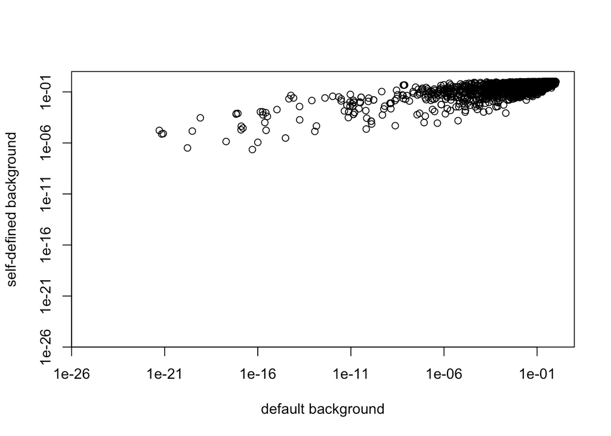

```r
tb1 = enrichGO(gene = diff_gene, ont = "BP", OrgDb = org.Hs.eg.db)
tb2 = enrichGO(gene = diff_gene, ont = "BP", OrgDb = org.Hs.eg.db, universe = bg_gene)

tb1 = tb1@result
tb2 = tb2@result
cn = intersect(tb1$ID, tb2$ID)

plot(tb1[cn, "pvalue"], tb2[cn, "pvalue"], log = "xy",
    xlim = c(1e-25, 1), ylim = c(1e-25, 1),
    xlab = "default background", ylab = "self-defined background")
```

Or overlap between the significant GO terms:

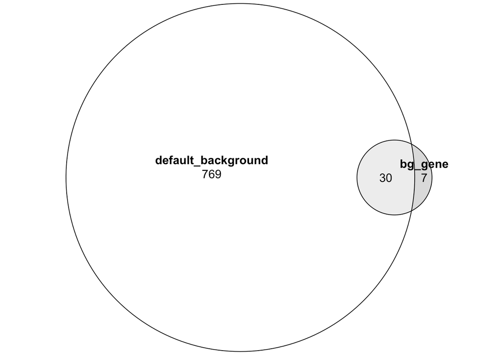

```r
library(eulerr)
plot(euler(list("default_background" = tb1$ID[tb1$p.adjust < 0.05],
                "bg_gene" = tb2$ID[tb2$p.adjust < 0.05])),
    quantities = TRUE)
```

## Example for other organism

1. GO enrichment

`enrichGO()` accepts an `OrgDb` object as the source of the GO gene sets. We take pig as an example. `random_genes()` is from **GSEAtraining** package.

```r
library(org.Ss.eg.db)
diff_gene = random_genes(org.Ss.eg.db, 1000, "ENTREZID")
```

Here we set `pvalueCutoff = 1, qvalueCutoff = 1` because genes are random genes and it is expected there won’t be too much significant terms left.

```r
tb = enrichGO(gene = diff_gene, ont = "BP", OrgDb = org.Ss.eg.db,
    pvalueCutoff = 1, qvalueCutoff = 1)
head(tb)
```

```
##                    ID                                      Description
## GO:0009067 GO:0009067 aspartate family amino acid biosynthetic process
## GO:2000243 GO:2000243      positive regulation of reproductive process
## GO:0007411 GO:0007411                                    axon guidance
## GO:0097485 GO:0097485                       neuron projection guidance
## GO:0009066 GO:0009066    aspartate family amino acid metabolic process
## GO:0001675 GO:0001675                                acrosome assembly
##            GeneRatio BgRatio RichFactor FoldEnrichment   zScore      pvalue
## GO:0009067     4/395 12/7920  0.3333333       6.683544 4.513953 0.002190543
## GO:2000243     7/395 41/7920  0.1707317       3.423279 3.564021 0.003755209
## GO:0007411    10/395 77/7920  0.1298701       2.603978 3.240285 0.004673322
## GO:0097485    10/395 77/7920  0.1298701       2.603978 3.240285 0.004673322
## GO:0009066     5/395 23/7920  0.2173913       4.358833 3.695743 0.004802035
## GO:0001675     4/395 17/7920  0.2352941       4.717796 3.515560 0.008639334
##             p.adjust    qvalue
## GO:0009067 0.9865981 0.9865981
## GO:2000243 0.9865981 0.9865981
## GO:0007411 0.9865981 0.9865981
## GO:0097485 0.9865981 0.9865981
## GO:0009066 0.9865981 0.9865981
## GO:0001675 0.9865981 0.9865981
##                                                                                                   geneID
## GO:0009067                                                          100525858/396967/100312961/100513955
## GO:2000243                                     397493/100513384/414285/100500718/100152834/397582/404696
## GO:0007411 100154710/100511780/100512643/733599/100524195/100101550/100511850/100337658/396712/100522873
## GO:0097485 100154710/100511780/100512643/733599/100524195/100101550/100511850/100337658/396712/100522873
## GO:0009066                                                100525698/100525858/396967/100312961/100513955
## GO:0001675                                                          100038012/100519805/397317/100519523
##            Count
## GO:0009067     4
## GO:2000243     7
## GO:0007411    10
## GO:0097485    10
## GO:0009066     5
## GO:0001675     4
```

2. KEGG enrichment

The KEGG code of a specific organism can be found at https://rest.kegg.jp/list/organism

```r
tb = enrichKEGG(gene = diff_gene, organism = "ssc", pvalueCutoff = 1, qvalueCutoff = 1)
head(tb)
```

```
##                                      category
## ssc04061 Environmental Information Processing
## ssc04613                   Organismal Systems
## ssc00561                           Metabolism
## ssc04015 Environmental Information Processing
## ssc04010 Environmental Information Processing
## ssc05322                       Human Diseases
##                                  subcategory       ID
## ssc04061 Signaling molecules and interaction ssc04061
## ssc04613                       Immune system ssc04613
## ssc00561                    Lipid metabolism ssc00561
## ssc04015                 Signal transduction ssc04015
## ssc04010                 Signal transduction ssc04010
## ssc05322                      Immune disease ssc05322
##                                                            Description
## ssc04061 Viral protein interaction with cytokine and cytokine receptor
## ssc04613                       Neutrophil extracellular trap formation
## ssc00561                                       Glycerolipid metabolism
## ssc04015                                        Rap1 signaling pathway
## ssc04010                                        MAPK signaling pathway
## ssc05322                                  Systemic lupus erythematosus
##          GeneRatio  BgRatio RichFactor FoldEnrichment   zScore      pvalue
## ssc04061    10/445  85/9198 0.11764706       2.431725 2.989944 0.007687205
## ssc04613    15/445 179/9198 0.08379888       1.732095 2.230176 0.026747983
## ssc00561     7/445  61/9198 0.11475410       2.371929 2.423925 0.027092181
## ssc04015    17/445 213/9198 0.07981221       1.649691 2.163030 0.029111638
## ssc04010    21/445 293/9198 0.07167235       1.481443 1.888368 0.045968863
## ssc05322    10/445 119/9198 0.08403361       1.736946 1.824379 0.062133274
##          p.adjust   qvalue
## ssc04061 0.983914 0.983914
## ssc04613 0.983914 0.983914
## ssc00561 0.983914 0.983914
## ssc04015 0.983914 0.983914
## ssc04010 0.983914 0.983914
## ssc05322 0.983914 0.983914
##                                                                                                                                                                                                            geneID
## ssc04061                                                                                                               100522695/414374/100524265/100310829/553951/100737977/100520680/396870/100037292/100135681
## ssc04613                                                          100625850/100522792/100622559/106510170/100512420/110260605/102159373/100622387/110258651/397384/100462749/100512769/733681/100522182/106504121
## ssc00561                                                                                                                                       100519533/100233171/396816/100156632/100524113/100152836/100233189
## ssc04015                                      100522792/100525013/100154710/100152116/100622559/100511843/100515047/110260605/100518983/100156660/100514949/100519821/100514402/110259378/733681/397509/100522873
## ssc04010 100517317/100522792/100525013/100154710/100152116/100521986/…
## ssc05322                                                                                                      100625850/106510170/100512420/100524872/100037955/100622387/100512769/100522182/106504121/100152189
##          Count
## ssc04061    10
## ssc04613    15
## ssc00561     7
## ssc04015    17
## ssc04010    21
## ssc05322    10
```

3. MSigDB

Use `msigdbr::msigdbr_species()` to see which organisms are supported.

```r
gene_sets = msigdbr(species = "pig", category = "H")
map = gene_sets[, c("gs_name", "entrez_gene")]
map$entrez_gene = as.character(map$entrez_gene)

tb = enricher(gene = diff_gene, TERM2GENE = map, pvalueCutoff = 1, qvalueCutoff = 1)
head(tb)
```

```
##                                                                    ID
## HALLMARK_PI3K_AKT_MTOR_SIGNALING     HALLMARK_PI3K_AKT_MTOR_SIGNALING
## HALLMARK_ESTROGEN_RESPONSE_EARLY     HALLMARK_ESTROGEN_RESPONSE_EARLY
## HALLMARK_NOTCH_SIGNALING                     HALLMARK_NOTCH_SIGNALING
## HALLMARK_G2M_CHECKPOINT                       HALLMARK_G2M_CHECKPOINT
## HALLMARK_ALLOGRAFT_REJECTION             HALLMARK_ALLOGRAFT_REJECTION
## HALLMARK_UNFOLDED_PROTEIN_RESPONSE HALLMARK_UNFOLDED_PROTEIN_RESPONSE
##                                                           Description GeneRatio
## HALLMARK_PI3K_AKT_MTOR_SIGNALING     HALLMARK_PI3K_AKT_MTOR_SIGNALING    12/217
## HALLMARK_ESTROGEN_RESPONSE_EARLY     HALLMARK_ESTROGEN_RESPONSE_EARLY    18/217
## HALLMARK_NOTCH_SIGNALING                     HALLMARK_NOTCH_SIGNALING     4/217
## HALLMARK_G2M_CHECKPOINT                       HALLMARK_G2M_CHECKPOINT    15/217
## HALLMARK_ALLOGRAFT_REJECTION             HALLMARK_ALLOGRAFT_REJECTION    15/217
## HALLMARK_UNFOLDED_PROTEIN_RESPONSE HALLMARK_UNFOLDED_PROTEIN_RESPONSE     9/217
##                                     BgRatio RichFactor FoldEnrichment   zScore
## HALLMARK_PI3K_AKT_MTOR_SIGNALING   103/4191 0.11650485       2.250101 3.001450
## HALLMARK_ESTROGEN_RESPONSE_EARLY   194/4191 0.09278351       1.791962 2.639131
## HALLMARK_NOTCH_SIGNALING            32/4191 0.12500000       2.414171 1.876313
## HALLMARK_G2M_CHECKPOINT            197/4191 0.07614213       1.470561 1.580766
## HALLMARK_ALLOGRAFT_REJECTION       198/4191 0.07575758       1.463134 1.559956
## HALLMARK_UNFOLDED_PROTEIN_RESPONSE 112/4191 0.08035714       1.551967 1.383465
##                                         pvalue  p.adjust    qvalue
## HALLMARK_PI3K_AKT_MTOR_SIGNALING   0.006398456 0.2620120 0.2620120
## HALLMARK_ESTROGEN_RESPONSE_EARLY   0.010694368 0.2620120 0.2620120
## HALLMARK_NOTCH_SIGNALING           0.080857970 0.8465437 0.8465437
## HALLMARK_G2M_CHECKPOINT            0.083540340 0.8465437 0.8465437
## HALLMARK_ALLOGRAFT_REJECTION       0.086382010 0.8465437 0.8465437
## HALLMARK_UNFOLDED_PROTEIN_RESPONSE 0.124127602 0.9611856 0.9611856
##                                                                                                                                                                                                        geneID
## HALLMARK_PI3K_AKT_MTOR_SIGNALING                                                               100522792/100515395/100152116/397493/397211/780418/100626761/100233194/100627936/100512677/110259378/100153160
## HALLMARK_ESTROGEN_RESPONSE_EARLY   397638/100625267/100520045/100312971/100157485/100156014/100126235/100154866/100526236/100738589/397547/397582/100620107/100153665/100127479/100157810/100521067/100156262
## HALLMARK_NOTCH_SIGNALING                                                                                                                                              100518735/100739198/100154978/100738589
## HALLMARK_G2M_CHECKPOINT                                          768108/100737376/100623146/100517138/100524872/100737380/100512756/100518587/100522031/100515361/100626110/397015/100738589/100156808/397266
## HALLMARK_ALLOGRAFT_REJECTION                                                 397053/100038007/100522792/414374/100524265/733650/100511843/414410/100135677/100514823/396639/733681/100135681/100522182/595126
## HALLMARK_UNFOLDED_PROTEIN_RESPONSE                                                                                  100151977/100620358/100519332/110257378/100526191/100171388/100622832/100523065/100312961
##                                    Count
## HALLMARK_PI3K_AKT_MTOR_SIGNALING      12
## HALLMARK_ESTROGEN_RESPONSE_EARLY      18
## HALLMARK_NOTCH_SIGNALING               4
## HALLMARK_G2M_CHECKPOINT               15
## HALLMARK_ALLOGRAFT_REJECTION          15
## HALLMARK_UNFOLDED_PROTEIN_RESPONSE     9
```

## Examples for less well-studied organisms

### When an `OrgDb` object is avaiable

You can use `enrichGO()` as long as you have an `OrgDb` object:

Taking dolphin as an example.

```r
library(AnnotationHub)
ah = AnnotationHub()
org_db = ah[["AH118180"]]
```

```
## loading from cache
```

```r
diff_gene = random_genes(org_db, 1000, "ENTREZID")
tb = enrichGO(diff_gene, ont = "BP", OrgDb = org_db,
    pvalueCutoff = 1, qvalueCutoff = 1)
head(tb)
```

```
##                    ID                                    Description GeneRatio
## GO:0051262 GO:0051262                        protein tetramerization     4/475
## GO:0044272 GO:0044272           sulfur compound biosynthetic process     7/475
## GO:0030488 GO:0030488                               tRNA methylation     4/475
## GO:0045860 GO:0045860 positive regulation of protein kinase activity     5/475
## GO:0006308 GO:0006308                          DNA catabolic process     3/475
## GO:0031365 GO:0031365     N-terminal protein amino acid modification     3/475
##             BgRatio RichFactor FoldEnrichment   zScore      pvalue p.adjust
## GO:0051262 16/13726  0.2500000       7.224211 4.716330 0.001850017 0.944717
## GO:0044272 66/13726  0.1060606       3.064817 3.183514 0.007609090 0.944717
## GO:0030488 26/13726  0.1538462       4.445668 3.329496 0.011566501 0.944717
## GO:0045860 41/13726  0.1219512       3.524005 3.064350 0.013048460 0.944717
## GO:0006308 15/13726  0.2000000       5.779368 3.506390 0.013738163 0.944717
## GO:0031365 15/13726  0.2000000       5.779368 3.506390 0.013738163 0.944717
##              qvalue
## GO:0051262 0.944717
## GO:0044272 0.944717
## GO:0030488 0.944717
## GO:0045860 0.944717
## GO:0006308 0.944717
## GO:0031365 0.944717
##                                                                           geneID
## GO:0051262                               109551822/101319351/101317439/101329250
## GO:0044272 101318630/101323391/101327219/101333698/101325198/101317120/101320949
## GO:0030488                               101318322/101320152/101334518/101333565
## GO:0045860                     101327555/101317224/101321385/101335095/101335462
## GO:0006308                                         101334559/117311726/101325484
## GO:0031365                                         101338879/101322089/101329421
##            Count
## GO:0051262     4
## GO:0044272     7
## GO:0030488     4
## GO:0045860     5
## GO:0006308     3
## GO:0031365     3
```

### enrichKEGG() also supports many other orgainsms

```r
enrichKEGG(gene = diff_gene, organism = ...)
```

### Manually construct the gene sets

We have introduced many ways to obtain gene sets for less well-studies organisms. The only thing to do here is to convert gene sets to a two-column data frame where gene sets are in the first column and genes are in the second column. Then use `enricher()`.

```r
enricher(diff_gene, TERM2GENE = ...)
```

## Look at the `tb` object

We used the same variable name `tb` for the object returned by the various enrichment functions. They are all in the same format. It looks like a table, but be careful, it is actually not:

```r
class(tb)
```

```
## [1] "enrichResult"
## attr(,"package")
## [1] "DOSE"
```

```r
str(tb)
```

```
## Formal class 'enrichResult' [package "DOSE"] with 15 slots
##   ..@ result       :'data.frame':    1479 obs. of  12 variables:
##   .. ..$ ID            : chr [1:1479] "GO:0051262" "GO:0044272" "GO:0030488" "GO:0045860" ...
##   .. ..$ Description   : chr [1:1479] "protein tetramerization" "sulfur compound biosynthetic process" "tRNA methylation" "positive regulation of protein kinase activity" ...
##   .. ..$ GeneRatio     : chr [1:1479] "4/475" "7/475" "4/475" "5/475" ...
##   .. ..$ BgRatio       : chr [1:1479] "16/13726" "66/13726" "26/13726" "41/13726" ...
##   .. ..$ RichFactor    : num [1:1479] 0.25 0.106 0.154 0.122 0.2 ...
##   .. ..$ FoldEnrichment: num [1:1479] 7.22 3.06 4.45 3.52 5.78 ...
##   .. ..$ zScore        : num [1:1479] 4.72 3.18 3.33 3.06 3.51 ...
##   .. ..$ pvalue        : num [1:1479] 0.00185 0.00761 0.01157 0.01305 0.01374 ...
##   .. ..$ p.adjust      : num [1:1479] 0.945 0.945 0.945 0.945 0.945 ...
##   .. ..$ qvalue        : num [1:1479] 0.945 0.945 0.945 0.945 0.945 ...
##   .. ..$ geneID        : chr [1:1479] "109551822/101319351/101317439/101329250" "101318630/101323391/101327219/101333698/101325198/101317120/101320949" "101318322/101320152/101334518/101333565" "101327555/101317224/101321385/101335095/101335462" ...
##   .. ..$ Count         : int [1:1479] 4 7 4 5 3 3 17 5 4 3 ...
##   ..@ pvalueCutoff : num 1
##   ..@ pAdjustMethod: chr "BH"
##   ..@ qvalueCutoff : num 1
##   ..@ organism     : chr "Tursiops truncatus"
##   ..@ ontology     : chr "BP"
##   ..@ gene         : chr [1:1000] "101326707" "117308140" "101336661" "117309415" ...
##   ..@ keytype      : chr "ENTREZID"
##   ..@ universe     : chr [1:13726] "101315666" "101325920" "101326047" "101328885" ...
##   ..@ gene2Symbol  : chr(0)
##   ..@ geneSets     :List of 1948
##   .. ..$ GO:0000002: chr [1:10] "101315666" "101325920" "101326047" "101328885" ...
##   .. ..$ GO:0000027: chr [1:33] "101315465" "101316856" "101319900" "101320222" ...
##   .. ..$ GO:0000028: chr [1:34] "101317415" "101318043" "101318467" "101318567" ...
##   .. ..$ GO:0000038: chr [1:24] "101318721" "101319800" "101320860" "101321283" ...
##   .. ..$ GO:0000041: chr [1:87] "101315672" "101316332" "101316680" "101316885" ...
##   .. ..$ GO:0000045: chr [1:44] "101316021" "101316129" "101317161" "101317562" ...
##   .. ..$ GO:0000054: chr [1:17] "101318918" "101319915" "101322461" "101323043" ...
##   .. ..$ GO:0000055: chr [1:9] "101323043" "101324936" "101332258" "101333049" ...
##   .. ..$ GO:0000056: chr [1:8] "101319915" "101323043" "101334636" "101335049" ...
##   .. ..$ GO:0000070: chr [1:69] "101315654" "101315716" "101316211" "101316537" ...
##   .. ..$ GO:0000075: chr [1:63] "101316695" "101316733" "101318624" "101319304" ...
##   .. ..$ GO:0000076: chr [1:13] "101316733" "101320717" "101320935" "101323238" ...
##   .. ..$ GO:0000077: chr [1:31] "101316733" "101319304" "101320252" "101320465" ...
##   .. ..$ GO:0000079: chr [1:38] "101316500" "101317117" "101319016" "101319831" ...
##   .. ..$ GO:0000086: chr [1:34] "101316733" "101318219" "101318851" "101319304" ...
##   .. ..$ GO:0000096: chr [1:19] "101317866" "101318072" "101318630" "101320181" ...
```

[output cut: 73 more lines]

```
##   .. ..$ GO:0002253: chr [1:115] "101315656" "101315672" "101316146" "101316337" ...
##   .. ..$ GO:0002263: chr [1:53] "101315662" "101317221" "101318525" "101319565" ...
##   .. ..$ GO:0002274: chr [1:23] "101319832" "101321866" "101327408" "101327989" ...
##   .. ..$ GO:0002275: chr [1:12] "101321866" "101327989" "101328790" "101328970" ...
##   .. ..$ GO:0002276: chr "101337474"
##   .. ..$ GO:0002285: chr [1:42] "101315662" "101317221" "101318525" "101319565" ...
##   .. ..$ GO:0002286: chr [1:33] "101315662" "101317221" "101320258" "101322889" ...
##   .. ..$ GO:0002309: chr "101315662"
##   .. ..$ GO:0002323: chr [1:24] "101320258" "101322076" "101325073" "109549914" ...
##   .. ..$ GO:0002366: chr [1:52] "101315662" "101317221" "101318525" "101319565" ...
##   .. .. [list output truncated]
##   ..@ readable     : logi FALSE
##   ..@ termsim      : num[0 , 0 ]
##   ..@ method       : chr(0)
##   ..@ dr           : list()
```

To convert it into a “real” table, DO NOT use `as.data.frame()` which only returns the significant terms, use `tb@result`.

Also some columns in `tb@result` are not in the proper format, e.g. `"GeneRatio"` and `"BgRatio"` where numbers should be in numeric mode while not characters. In **GSEAtraining**, there is a `add_more_columns()` which adds more columns to the `tb@result` table.

```r
tb2 = add_more_columns(tb)
head(tb2@result)
```

```
##                    ID                                    Description GeneRatio
## GO:0051262 GO:0051262                        protein tetramerization     4/475
## GO:0044272 GO:0044272           sulfur compound biosynthetic process     7/475
## GO:0030488 GO:0030488                               tRNA methylation     4/475
## GO:0045860 GO:0045860 positive regulation of protein kinase activity     5/475
## GO:0006308 GO:0006308                          DNA catabolic process     3/475
## GO:0031365 GO:0031365     N-terminal protein amino acid modification     3/475
##             BgRatio RichFactor FoldEnrichment   zScore      pvalue p.adjust
## GO:0051262 16/13726  0.2500000       7.224211 4.716330 0.001850017 0.944717
## GO:0044272 66/13726  0.1060606       3.064817 3.183514 0.007609090 0.944717
## GO:0030488 26/13726  0.1538462       4.445668 3.329496 0.011566501 0.944717
## GO:0045860 41/13726  0.1219512       3.524005 3.064350 0.013048460 0.944717
## GO:0006308 15/13726  0.2000000       5.779368 3.506390 0.013738163 0.944717
## GO:0031365 15/13726  0.2000000       5.779368 3.506390 0.013738163 0.944717
##              qvalue
## GO:0051262 0.944717
## GO:0044272 0.944717
## GO:0030488 0.944717
## GO:0045860 0.944717
## GO:0006308 0.944717
## GO:0031365 0.944717
##                                                                           geneID
## GO:0051262                               109551822/101319351/101317439/101329250
## GO:0044272 101318630/101323391/101327219/101333698/101325198/101317120/101320949
## GO:0030488                               101318322/101320152/101334518/101333565
## GO:0045860                     101327555/101317224/101321385/101335095/101335462
## GO:0006308                                         101334559/117311726/101325484
## GO:0031365                                         101338879/101322089/101329421
##            Count n_hits n_genes gs_size n_totle log2_fold_enrichment  z_score
## GO:0051262     4      4     475      16   13726             2.852840 4.716330
## GO:0044272     7      7     475      66   13726             1.615801 3.183514
## GO:0030488     4      4     475      26   13726             2.152400 3.329496
## GO:0045860     5      5     475      41   13726             1.817216 3.064350
## GO:0006308     3      3     475      15   13726             2.530912 3.506390
## GO:0031365     3      3     475      15   13726             2.530912 3.506390
```

## Practice

#### Practice 1

Use the DE gene list in `webgestalt_example_gene_list.rds` to perform ORA on GO/KEGG/MSigDB gene sets.

```r
genes = readRDS(system.file("extdata", "webgestalt_example_gene_list.rds",
    package = "GSEAtraining"))
```